# A naive TCR:pMHC interaction model

```r
library(data.table)
library(ggplot2)
library(reshape2)
library(dplyr)
library(ggbeeswarm)
library(RColorBrewer)
library(pROC)
library(stringr)
library(gplots)
```

```r
df = fread("../result/structure.txt", header=T, sep="\t")[tcr_region %in% c("CDR1", "CDR2", "CDR3")]

df$tcr_chain = as.factor(substr(as.character(df$tcr_v_allele), 1, 3))
df$contact = df$distance <= 4.5
df$aa_pair = with(df,
  as.factor(ifelse(as.character(aa_tcr) < as.character(aa_antigen), paste(aa_tcr, aa_antigen, sep = "_"), paste(aa_antigen, aa_tcr, sep = "_"))))
summary(df)
```

```
    pdb_id            species            mhc_type         mhc_a_allele       mhc_b_allele       antigen_seq        tcr_v_allele
 Length:62077       Length:62077       Length:62077       Length:62077       Length:62077       Length:62077       Length:62077
 Class :character   Class :character   Class :character   Class :character   Class :character   Class :character   Class :character
 Mode  :character   Mode  :character   Mode  :character   Mode  :character   Mode  :character   Mode  :character   Mode  :character




  tcr_region        tcr_region_seq        aa_tcr           aa_antigen           len_tcr       len_antigen       pos_tcr        pos_antigen
 Length:62077       Length:62077       Length:62077       Length:62077       Min.   : 3.00   Min.   : 8.00   Min.   : 0.000   Min.   : 0.000
 Class :character   Class :character   Class :character   Class :character   1st Qu.: 6.00   1st Qu.: 9.00   1st Qu.: 1.000   1st Qu.: 2.000
 Mode  :character   Mode  :character   Mode  :character   Mode  :character   Median :12.00   Median :10.00   Median : 4.000   Median : 5.000
                                                                             Mean   :10.33   Mean   :10.94   Mean   : 4.663   Mean   : 4.971
                                                                             3rd Qu.:14.00   3rd Qu.:13.00   3rd Qu.: 7.000   3rd Qu.: 7.000
                                                                             Max.   :18.00   Max.   :20.00   Max.   :17.000   Max.   :19.000

    distance        distance_CA       distance_CB          energy         tcr_chain    contact           aa_pair
 Min.   :  2.231   Min.   :  3.696   Min.   :  2.164   Min.   :-76.1000   TRA:30674   Mode :logical   L_S    : 1232
 1st Qu.: 10.622   1st Qu.: 13.907   1st Qu.: 13.952   1st Qu.:  0.0000   TRB:31403   FALSE:59961     G_S    : 1200
 Median : 15.135   Median : 18.415   Median : 18.757   Median :  0.0000               TRUE :2116      G_L    : 1146
 Mean   : 17.691   Mean   : 20.927   Mean   : 21.205   Mean   : -0.2774               NA's :0         A_G    : 1047
 3rd Qu.: 20.351   3rd Qu.: 23.483   3rd Qu.: 24.256   3rd Qu.:  0.0000                               A_S    :  902
 Max.   :126.207   Max.   :129.029   Max.   :132.255   Max.   :774.0000                               G_Y    :  869
                                                       NA's   :160                                    (Other):55681
```

# Some EDA

## Contact distribution

Contacts by MHC, chain and CDR

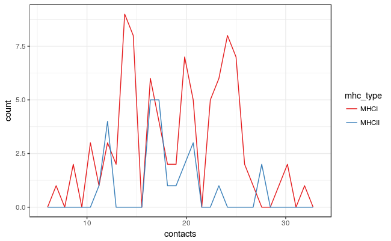

```r
df.contact.sum = df[,.(contacts = sum(contact)),by=.(pdb_id, tcr_chain, tcr_region, mhc_type)]
df.contact.sum.pdb = df.contact.sum[,.(contacts = sum(contacts)), by=.(pdb_id, mhc_type)][contacts>5]
ggplot(df.contact.sum.pdb, aes(contacts, color = mhc_type)) +
  geom_freqpoly() +
  scale_color_brewer(palette = "Set1") +
  theme_bw()
```

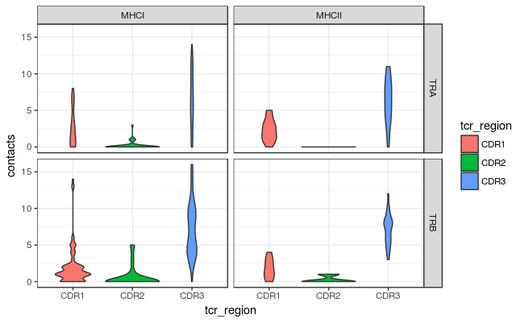

```r
df.contact.sum = df.contact.sum[pdb_id %in% df.contact.sum.pdb$pdb_id]
ggplot(df.contact.sum, aes(x=tcr_region, group = tcr_region, y = contacts, fill = tcr_region)) +
  geom_violin() +
  facet_grid(tcr_chain~mhc_type) +
  theme_bw()
```

```r
a = aov(contacts~tcr_chain*tcr_region*mhc_type, df.contact.sum)
anova(a)
```

```
Analysis of Variance Table

Response: contacts
                               Df Sum Sq Mean Sq  F value    Pr(>F)
tcr_chain                       1    2.3    2.35   0.3763  0.539802
tcr_region                      2 4994.2 2497.09 400.0655 < 2.2e-16 ***
mhc_type                        1    5.3    5.34   0.8561  0.355160
tcr_chain:tcr_region            2   61.7   30.85   4.9432  0.007396 **
tcr_chain:mhc_type              1    0.3    0.26   0.0419  0.837848
tcr_region:mhc_type             2    0.2    0.10   0.0160  0.984121
tcr_chain:tcr_region:mhc_type   2    0.8    0.40   0.0642  0.937830
Residuals                     665 4150.7    6.24
---
Signif. codes:  0 ‘***’ 0.001 ‘**’ 0.01 ‘*’ 0.05 ‘.’ 0.1 ‘ ’ 1
```

```r
TukeyHSD(a, "tcr_region")
```

```
  Tukey multiple comparisons of means
    95% family-wise confidence level

Fit: aov(formula = contacts ~ tcr_chain * tcr_region * mhc_type, data = df.contact.sum)

$tcr_region
               diff       lwr       upr p adj
CDR2-CDR1 -1.901461 -2.454139 -1.348784     0
CDR3-CDR1  4.570796  4.018732  5.122861     0
CDR3-CDR2  6.472258  5.919580  7.024935     0
```

```r
TukeyHSD(a, "tcr_chain:tcr_region")
```

```
  Tukey multiple comparisons of means
    95% family-wise confidence level

Fit: aov(formula = contacts ~ tcr_chain * tcr_region * mhc_type, data = df.contact.sum)

$`tcr_chain:tcr_region`
                        diff        lwr        upr     p adj
TRB:CDR1-TRA:CDR1 -0.7078242 -1.6577655  0.2421171 0.2732468
TRA:CDR2-TRA:CDR1 -2.4499303 -3.4019897 -1.4978710 0.0000000
TRB:CDR2-TRA:CDR1 -2.0620171 -3.0119584 -1.1120758 0.0000000
TRA:CDR3-TRA:CDR1  3.8672566  2.9173153  4.8171979 0.0000000
TRB:CDR3-TRA:CDR1  4.5665121  3.6165708  5.5164534 0.0000000
TRA:CDR2-TRB:CDR1 -1.7421061 -2.6941655 -0.7900468 0.0000034
TRB:CDR2-TRB:CDR1 -1.3541930 -2.3041343 -0.4042517 0.0007328
TRA:CDR3-TRB:CDR1  4.5750808  3.6251395  5.5250221 0.0000000
TRB:CDR3-TRB:CDR1  5.2743363  4.3243950  6.2242776 0.0000000
TRB:CDR2-TRA:CDR2  0.3879132 -0.5641462  1.3399725 0.8535634
TRA:CDR3-TRA:CDR2  6.3171869  5.3651276  7.2692463 0.0000000
TRB:CDR3-TRA:CDR2  7.0164424  6.0643831  7.9685018 0.0000000
TRA:CDR3-TRB:CDR2  5.9292738  4.9793325  6.8792151 0.0000000
TRB:CDR3-TRB:CDR2  6.6285292  5.6785879  7.5784706 0.0000000
TRB:CDR3-TRA:CDR3  0.6992555 -0.2506858  1.6491968 0.2864734
```

Filter TCRs with no contacts

```r
df = df[pdb_id %in% df.contact.sum.pdb$pdb_id ]
```

Contact distribution on antigen

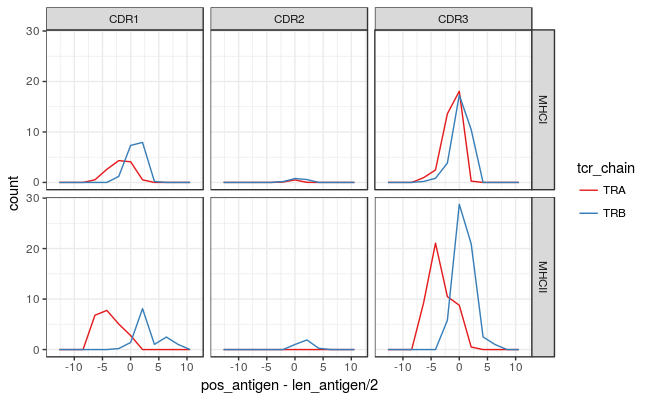

```r
df.contact.dist.ag = df[,
                        .(contacts = sum(contact), total.pdb = length(unique(pdb_id))),
                        by=.(tcr_chain, tcr_region, mhc_type, pos_antigen, len_antigen)]
ggplot(df.contact.dist.ag, aes(x = pos_antigen - len_antigen / 2, weight = contacts / total.pdb, color = tcr_chain)) +
  geom_freqpoly(bins=10) +
  facet_grid(mhc_type~tcr_region) +
  scale_color_brewer(palette = "Set1") +
  theme_bw()
```

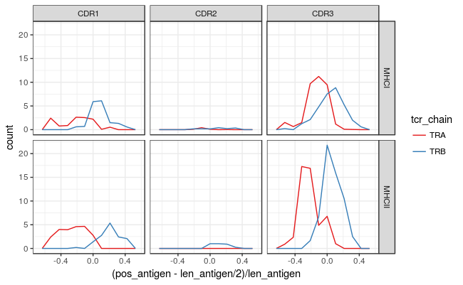

```r
ggplot(df.contact.dist.ag, aes(x = (pos_antigen - len_antigen / 2) / len_antigen, weight = contacts / total.pdb, color = tcr_chain)) +
  geom_freqpoly(bins=10) +
  facet_grid(mhc_type~tcr_region) +
  scale_color_brewer(palette = "Set1") +
  theme_bw()
```

vs antigen length

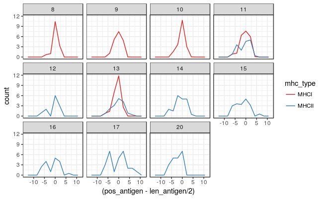

```r
df.contact.dist.ag.len = df[,
                        .(contacts = sum(contact), total.pdb = length(unique(pdb_id))),
                        by=.(pos_antigen, len_antigen, mhc_type)]
ggplot(df.contact.dist.ag.len, aes(x = (pos_antigen - len_antigen / 2), group = paste(len_antigen,mhc_type),
                                   weight = contacts / total.pdb, color = mhc_type)) +
  geom_freqpoly(bins=10) +
  facet_wrap(~len_antigen) +
  scale_color_brewer(palette = "Set1") +
  theme_bw()
```

Contact distribution on TCR

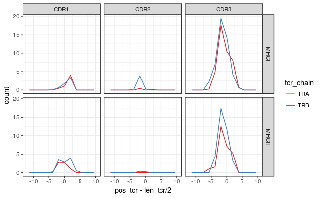

```r
df.contact.dist.tcr = df[,
                        .(contacts = sum(contact), total.pdb = length(unique(pdb_id))),
                        by=.(tcr_chain, tcr_region, mhc_type, pos_tcr, len_tcr)]
ggplot(df.contact.dist.tcr, aes(x = pos_tcr - len_tcr / 2, weight = contacts / total.pdb, color = tcr_chain)) +
  geom_freqpoly(bins=10) +
  facet_grid(mhc_type~tcr_region) +
  scale_color_brewer(palette = "Set1") +
  theme_bw()
```

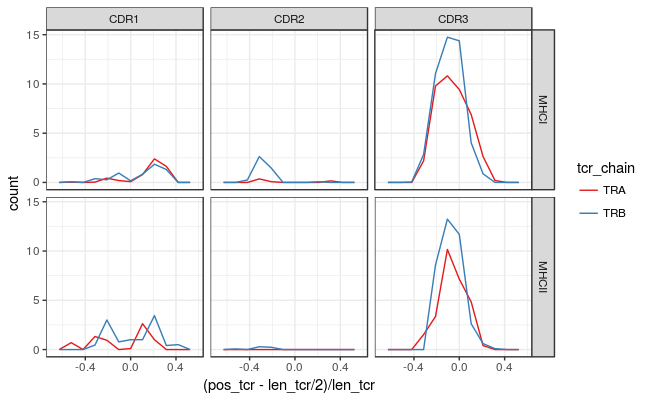

```r
ggplot(df.contact.dist.tcr, aes(x = (pos_tcr - len_tcr / 2) / len_tcr, weight = contacts / total.pdb, color = tcr_chain)) +
  geom_freqpoly(bins=10) +
  facet_grid(mhc_type~tcr_region) +
  scale_color_brewer(palette = "Set1") +
  theme_bw()
```

vs CDR3 len

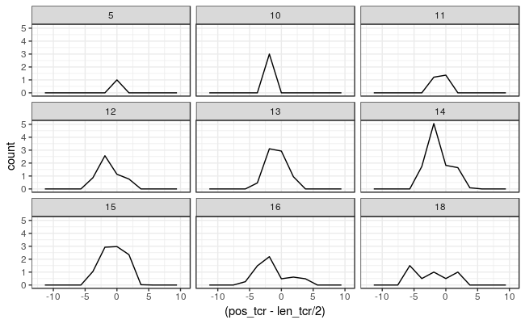

```r
df.contact.dist.tcr.len = df[tcr_region == "CDR3",
                        .(contacts = sum(contact), total.pdb = length(unique(pdb_id))),
                        by=.(pos_tcr, len_tcr)]
ggplot(df.contact.dist.tcr.len, aes(x = (pos_tcr - len_tcr / 2), group = len_tcr, weight = contacts / total.pdb)) +
  geom_freqpoly(bins=10) +
  facet_wrap(~len_tcr) +
  theme_bw()
```

## Amino acid pairs in contacts

# Modelling

Center coordinates

```r
df.pred = df
df.pred$pos_tcr_c = with(df.pred, pos_tcr - round(len_tcr/2))
df.pred$pos_antigen_c = with(df.pred, pos_antigen - round(len_antigen/2))
```

## Calpha distance model

### Simple mean model

Mean Calpha distances for centered coordinates

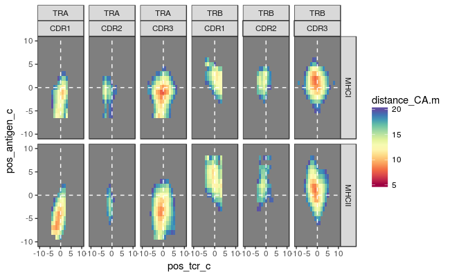

```r
df.ca.mean = df.pred[,.(distance_CA.m = mean(distance_CA)),
                        by=.(tcr_chain, tcr_region, mhc_type, pos_tcr_c, pos_antigen_c)]
ggplot(df.ca.mean, aes(x=pos_tcr_c, y=pos_antigen_c, fill=distance_CA.m)) +
  geom_tile() +
  geom_vline(xintercept = 0, linetype = "dashed", color = "white") +
  geom_hline(yintercept = 0, linetype = "dashed", color = "white") +
  facet_grid(mhc_type~tcr_chain+tcr_region) +
  scale_x_continuous(limits=c(-10,10)) +
  scale_y_continuous(limits=c(-10,10)) +
  scale_fill_gradientn(colors=colorRampPalette(brewer.pal(11, 'Spectral'))(32), limits=c(5, 20)) +
  theme_bw() +
  theme(panel.background = element_rect(fill = 'grey50'),
        panel.grid.major = element_blank(), panel.grid.minor = element_blank())
```

### Checking the model

Add mean distance values

```r
df.pred = df.pred[as.data.table(df.ca.mean), on = .(tcr_chain, tcr_region, mhc_type, pos_tcr_c, pos_antigen_c)]
```

Compare to true Calpha distance values

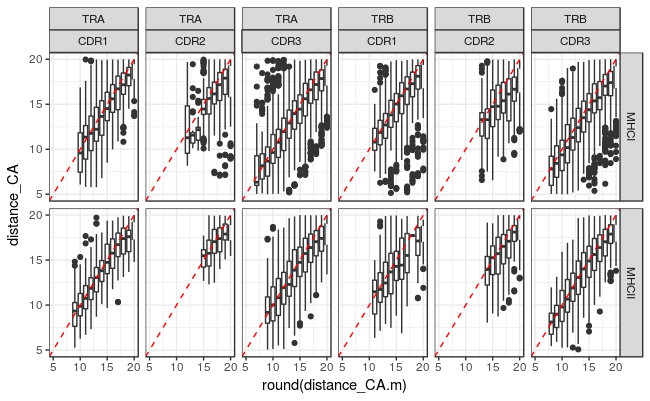

```r
ggplot(df.pred, aes(x=round(distance_CA.m), group = round(distance_CA.m), y = distance_CA)) +
  geom_boxplot() +
  geom_abline(slope = 1, intercept = 0, color = "red", linetype = "dashed") +
  scale_x_continuous(limits=c(5,20)) +
  scale_y_continuous(limits=c(5,20)) +
  facet_grid(mhc_type~tcr_chain+tcr_region) +
  theme_bw()
```

```r
summary(lm(distance_CA ~ distance_CA.m, df.pred))
```

```
Call:
lm(formula = distance_CA ~ distance_CA.m, data = df.pred)

Residuals:
    Min      1Q  Median      3Q     Max
-13.994  -1.898  -0.134   1.658  40.683

Coefficients:
                Estimate Std. Error t value Pr(>|t|)
(Intercept)   -2.031e-12  4.828e-02     0.0        1
distance_CA.m  1.000e+00  2.557e-03   391.1   <2e-16 ***
---
Signif. codes:  0 ‘***’ 0.001 ‘**’ 0.01 ‘*’ 0.05 ‘.’ 0.1 ‘ ’ 1

Residual standard error: 3.262 on 55887 degrees of freedom
Multiple R-squared:  0.7324,    Adjusted R-squared:  0.7324
F-statistic: 1.529e+05 on 1 and 55887 DF,  p-value: < 2.2e-16
```

Plot distance distribution for contacts and non-contacts, for real and estimated distances:

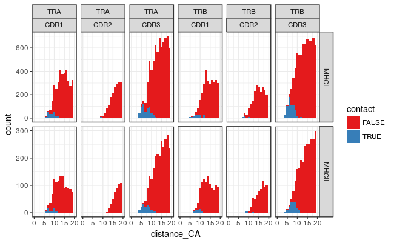

```r
ggplot(df.pred, aes(x = distance_CA, fill = contact)) +
  geom_histogram(binwidth = 1) +
  facet_grid(mhc_type~tcr_chain+tcr_region, scales="free_y") +
  scale_x_continuous(limits=c(0,20))+
  scale_fill_brewer(palette = "Set1") +
  theme_bw()
```

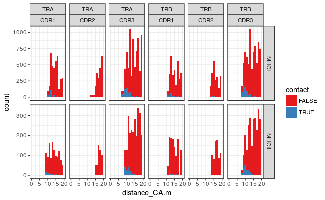

```r
ggplot(df.pred, aes(x = distance_CA.m, fill = contact)) +
  geom_histogram(binwidth = 1) +
  facet_grid(mhc_type~tcr_chain+tcr_region, scales="free_y") +
  scale_x_continuous(limits=c(0,20))+
  scale_fill_brewer(palette = "Set1") +
  theme_bw()
```

## Amino acid preferences and Calpha distance

Using a generalized linear model to fit contacts, operate with amino acid pairs, ignoring which one is in TCR and which one comes from antigen.

```r
res = glm(contact ~ distance_CA + aa_pair + 0, family = binomial(), data = df.pred)
```

```
glm.fit: fitted probabilities numerically 0 or 1 occurred
```

```r
summary(res)
```

```
Call:
glm(formula = contact ~ distance_CA + aa_pair + 0, family = binomial(),
    data = df.pred)

Deviance Residuals:
    Min       1Q   Median       3Q      Max
-3.2988  -0.0306  -0.0024  -0.0001   3.5854

Coefficients:
             Estimate Std. Error z value Pr(>|z|)
distance_CA   -1.1641     0.0239 -48.697  < 2e-16 ***
aa_pairA_A     7.4506     0.6490  11.480  < 2e-16 ***
aa_pairA_C    -5.0823   780.4740  -0.007 0.994804
aa_pairA_D     6.5046     1.0711   6.073 1.25e-09 ***
aa_pairA_E     8.0084     0.6800  11.778  < 2e-16 ***
aa_pairA_F     8.0345     0.5030  15.973  < 2e-16 ***
aa_pairA_G     6.2345     0.4301  14.495  < 2e-16 ***
aa_pairA_H    10.6128     0.7373  14.394  < 2e-16 ***
aa_pairA_I     7.6925     0.7669  10.031  < 2e-16 ***
aa_pairA_K     9.5920     0.7834  12.244  < 2e-16 ***
aa_pairA_L     8.8465     0.3937  22.473  < 2e-16 ***
aa_pairA_M    -5.9568  1130.5277  -0.005 0.995796
aa_pairA_N     7.3236     0.5978  12.251  < 2e-16 ***
aa_pairA_P     7.2898     0.6451  11.300  < 2e-16 ***
aa_pairA_Q     9.8584     0.3929  25.089  < 2e-16 ***
aa_pairA_R     8.9961     0.4562  19.718  < 2e-16 ***
aa_pairA_S     6.5389     0.4515  14.482  < 2e-16 ***
aa_pairA_T     7.2314     0.4943  14.629  < 2e-16 ***
aa_pairA_V     8.3448     0.5171  16.138  < 2e-16 ***
aa_pairA_W     8.1996     0.7161  11.451  < 2e-16 ***
aa_pairA_Y     9.6342     0.4171  23.100  < 2e-16 ***
aa_pairC_C     5.5391  2779.5674   0.002 0.998410
aa_pairC_D    -6.8313  1132.6530  -0.006 0.995188
aa_pairC_E    -2.0493   926.5239  -0.002 0.998235
aa_pairC_F    -0.7815   797.9707  -0.001 0.999219
aa_pairC_G     9.2124     1.2538   7.348 2.02e-13 ***
aa_pairC_H    -4.3174  2039.2983  -0.002 0.998311
aa_pairC_I    -3.0568   862.9445  -0.004 0.997174
aa_pairC_K     4.2483  1806.6199   0.002 0.998124
aa_pairC_L    -3.0819   592.3562  -0.005 0.995849
```

[output cut: 166 more lines]

```
aa_pairS_S     8.0212     0.7304  10.983  < 2e-16 ***
aa_pairS_T     7.7769     0.6008  12.944  < 2e-16 ***
aa_pairS_V     8.1070     0.4649  17.438  < 2e-16 ***
aa_pairS_W     8.8810     0.5756  15.428  < 2e-16 ***
 [ reached getOption("max.print") -- omitted 11 rows ]
---
Signif. codes:  0 ‘***’ 0.001 ‘**’ 0.01 ‘*’ 0.05 ‘.’ 0.1 ‘ ’ 1

(Dispersion parameter for binomial family taken to be 1)

    Null deviance: 77478.6  on 55889  degrees of freedom
Residual deviance:  5776.2  on 55678  degrees of freedom
AIC: 6198.2

Number of Fisher Scoring iterations: 19
```

Explore results

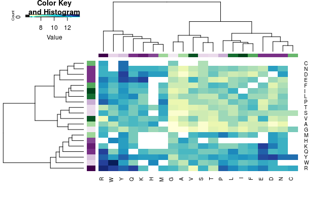

```r
coef = res$coefficients
pvalue = coef(summary(res))[,4]
coef = ifelse(pvalue < 0.05, coef, NA)
names(coef) = str_split_fixed(names(coef), "aa_pair", 2)[,2]
df.coef = data.frame(coef = coef,
                     aa_1 = str_split_fixed(names(coef), "_", 2)[, 1],
                     aa_2 = str_split_fixed(names(coef), "_", 2)[ ,2]) %>%
  filter(aa_1 != "" & aa_2 != "") %>%
  droplevels
df.coef.1 = df.coef
df.coef.1$aa_pair = with(df.coef.1,
  as.factor(ifelse(as.character(aa_1) < as.character(aa_2), paste(aa_1, aa_2, sep = "_"), paste(aa_2, aa_1, sep = "_"))))
df.coef.1 = df.coef.1 %>%
  select(aa_pair, coef)
df.coef2 = df.coef
df.coef2$aa_1 = df.coef$aa_2
df.coef2$aa_2 = df.coef$aa_1
df.coef = rbind(df.coef, df.coef2)
# transform to matrix and plot heatmap.2
aa_pair_mat = dcast(df.coef, aa_1 ~ aa_2, value.var = "coef", fun.aggregate = mean)
rownames(aa_pair_mat) = aa_pair_mat$aa_1
aa_pair_mat$aa_1 = NULL
aa_pair_mat = as.matrix(aa_pair_mat)
df.hydro <- data.frame(
  aa = strsplit("I V L F C M A W G T S Y P H N D Q E K R", " ")[[1]],
  hydrop = strsplit("4.5 4.2 3.8 2.8 2.5 1.9 1.8 -0.9 -0.4 -0.7 -0.8 -1.3 -1.6 -3.2 -3.5 -3.5 -3.5 -3.5 -3.9 -4.5", " ")[[1]]
)
df.hydro = df.hydro %>%
  mutate(hydrop = as.numeric(as.character(hydrop))) %>%
  arrange(hydrop) %>%
  mutate(hydrop.sc = round(100 * (hydrop - min(hydrop)) / (max(hydrop) - min(hydrop))))
df.hydro$color = colorRampPalette(brewer.pal(11, 'PRGn'))(101)[df.hydro$hydrop.sc + 1]
aa_colors = df.hydro$color
names(aa_colors) = df.hydro$aa
heatmap.2(aa_pair_mat,
          hclustfun = function(x) hclust(x, method = "ward.D2"),
          RowSideColors = aa_colors[rownames(aa_pair_mat)],
          ColSideColors = aa_colors[colnames(aa_pair_mat)],
          trace = "none",
          #breaks = seq(-16, -7, length.out = 101),
          col=colorRampPalette(brewer.pal(9, 'YlGnBu'))(32))
```

> TODO: smooth heatmap using KNN

Append amino acid distance coefficients

```r
df.pred = df.pred[df.coef.1, on = "aa_pair"]
df.pred.trimmed = df.pred[distance_CA <= 15] # discard AAs that are too far away for training
```

## Contact energies

Compute mean GROMACS energies

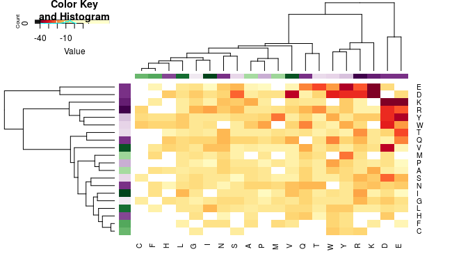

```r
df.energies = df[contact == T, .(energy.mean = mean(ifelse(energy > 0 , 0, energy))), by = "aa_pair"]
df.energies$aa_tcr = str_split_fixed(as.character(df.energies$aa_pair), "_", 2)[, 1]
df.energies$aa_antigen = str_split_fixed(as.character(df.energies$aa_pair), "_", 2)[, 2]
df.energies.tmp = df.energies
df.energies.tmp$aa_tcr = df.energies$aa_antigen
df.energies.tmp$aa_antigen = df.energies$aa_tcr
df.energies = rbind(df.energies, df.energies.tmp)
# transform to matrix and plot heatmap.2
aa_pair_energy_mat = dcast(df.energies, aa_tcr ~ aa_antigen, value.var = "energy.mean", fun.aggregate = mean)
rownames(aa_pair_energy_mat) = aa_pair_energy_mat$aa_tcr
aa_pair_energy_mat$aa_tcr = NULL
aa_pair_energy_mat = as.matrix(aa_pair_energy_mat)
heatmap.2(aa_pair_energy_mat,
          hclustfun = function(x) hclust(x, method = "ward.D2"),
          RowSideColors = aa_colors[rownames(aa_pair_mat)],
          ColSideColors = aa_colors[colnames(aa_pair_mat)],
          trace = "none",
          breaks = seq(-40, 2, length.out = 33),
          col=rev(colorRampPalette(brewer.pal(9, 'YlOrRd'))(32)))
```

# Building and testing a predictor

Final generalized linear model to fit contacts.

```r
# Train on a trimmed dataset
res_final = glm(contact ~ distance_CA.m + coef, family = binomial(), data = df.pred.trimmed)
summary(res_final)
```

```
Call:
glm(formula = contact ~ distance_CA.m + coef, family = binomial(),
    data = df.pred.trimmed)

Deviance Residuals:
    Min       1Q   Median       3Q      Max
-2.1271  -0.4980  -0.3149  -0.1694   3.7497

Coefficients:
              Estimate Std. Error z value Pr(>|z|)
(Intercept)   -0.68268    0.19461  -3.508 0.000452 ***
distance_CA.m -0.47137    0.01239 -38.044  < 2e-16 ***
coef           0.47245    0.01844  25.624  < 2e-16 ***
---
Signif. codes:  0 ‘***’ 0.001 ‘**’ 0.01 ‘*’ 0.05 ‘.’ 0.1 ‘ ’ 1

(Dispersion parameter for binomial family taken to be 1)

    Null deviance: 13079  on 18252  degrees of freedom
Residual deviance: 10668  on 18250  degrees of freedom
  (596 observations deleted due to missingness)
AIC: 10674

Number of Fisher Scoring iterations: 6
```

```r
df.pred.trimmed$p = predict(res_final, df.pred.trimmed, type="response")
df.pred$p = predict(res_final, df.pred, type="response")
df.pred = df.pred[df.energies, on = .(aa_tcr, aa_antigen)]
```

## Check accuracy

### General

ROC curve

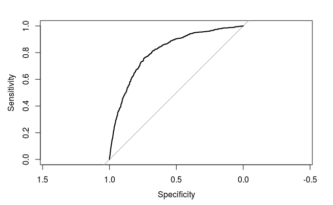

```r
rocobj = plot.roc(as.data.frame(df.pred.trimmed)[,"contact"], df.pred.trimmed$p, ci=T)
```

```r
rocobj
```

```
Call:
plot.roc.default(x = as.data.frame(df.pred.trimmed)[, "contact"],     predictor = df.pred.trimmed$p, ci = T)

Data: df.pred.trimmed$p in 16141 controls (as.data.frame(df.pred.trimmed)[, "contact"] FALSE) < 2112 cases (as.data.frame(df.pred.trimmed)[, "contact"] TRUE).
Area under the curve: 0.809
95% CI: 0.7994-0.8185 (DeLong)
```

Compute true and estimated total number of contacts

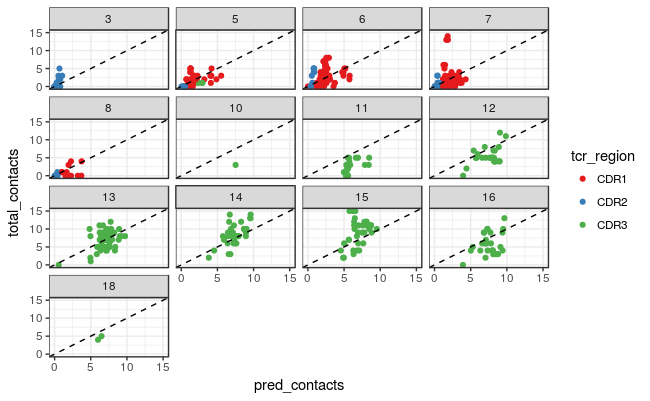

```r
df.pred.contsum = df.pred.trimmed[, .(total_contacts = sum(contact), pred_contacts = sum(p, na.rm=T)), by = .(pdb_id, tcr_region, mhc_type, tcr_chain, len_tcr)]
ggplot(df.pred.contsum, aes(x=pred_contacts, y=total_contacts, color = tcr_region)) +
  geom_point() +
  geom_abline(slope = 1, intercept = 0, linetype = "dashed") +

  scale_x_continuous(limits=c(0,15)) +
  scale_y_continuous(limits=c(0,15)) +
  scale_color_brewer(palette = "Set1") +
  facet_wrap(~len_tcr) +
  theme_bw()
```

```r
lfit = lm(total_contacts ~ pred_contacts + len_tcr + tcr_region - 1, df.pred.contsum)
summary(lfit)
```

```
Call:
lm(formula = total_contacts ~ pred_contacts + len_tcr + tcr_region -
    1, data = df.pred.contsum)

Residuals:
    Min      1Q  Median      3Q     Max
-5.9314 -1.2572 -0.1719  0.7878 11.7296

Coefficients:
               Estimate Std. Error t value Pr(>|t|)
pred_contacts   0.84078    0.08811   9.542  < 2e-16 ***
len_tcr         0.26766    0.06048   4.426 1.13e-05 ***
tcr_regionCDR1 -1.12580    0.40841  -2.757 0.006005 **
tcr_regionCDR2 -0.96886    0.28759  -3.369 0.000799 ***
tcr_regionCDR3 -2.74663    0.93172  -2.948 0.003314 **
---
Signif. codes:  0 ‘***’ 0.001 ‘**’ 0.01 ‘*’ 0.05 ‘.’ 0.1 ‘ ’ 1

Residual standard error: 2.306 on 650 degrees of freedom
Multiple R-squared:  0.7816,    Adjusted R-squared:  0.7799
F-statistic: 465.2 on 5 and 650 DF,  p-value: < 2.2e-16
```

```r
anova(lfit)
```

```
Analysis of Variance Table

Response: total_contacts
               Df  Sum Sq Mean Sq   F value    Pr(>F)
pred_contacts   1 12243.6 12243.6 2302.7585 < 2.2e-16 ***
len_tcr         1    56.5    56.5   10.6301  0.001171 **
tcr_region      3    65.8    21.9    4.1279  0.006493 **
Residuals     650  3456.0     5.3
---
Signif. codes:  0 ‘***’ 0.001 ‘**’ 0.01 ‘*’ 0.05 ‘.’ 0.1 ‘ ’ 1
```

### Examples from the train data

Check for a couple of antigens, GLCTLVAML

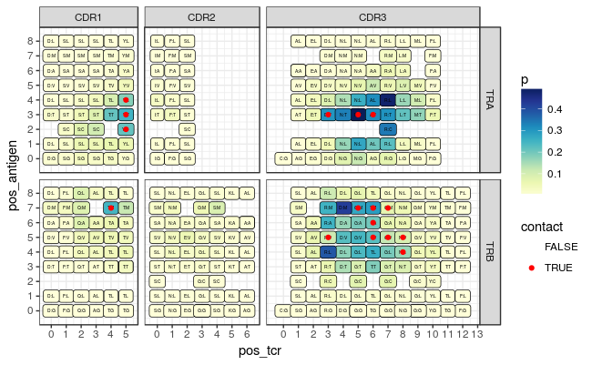

```r
df.pred.glc = df.pred %>%
  filter(antigen_seq == "GLCTLVAML") %>%
  droplevels()
ggplot(df.pred.glc, aes(x=pos_tcr, y=pos_antigen)) +
  geom_tile(fill=NA) +
  geom_label(aes(label=paste(aa_tcr, aa_antigen, sep=":"), fill = p), cex=1.3) +
  geom_point(aes(color=contact)) +
  scale_x_continuous(breaks=0:20) +
  scale_y_continuous(breaks=0:20) +
  #scale_fill_gradient("P",
  #                    low="white", high="#045a8d") +
  scale_color_manual(values = c(NA, "red")) +
  scale_fill_gradientn(colors=colorRampPalette(brewer.pal(9, 'YlGnBu'))(32)) +
  facet_grid(tcr_chain ~ tcr_region, scales="free", space="free") +
  theme_bw()
```

and LLFGYPVAV

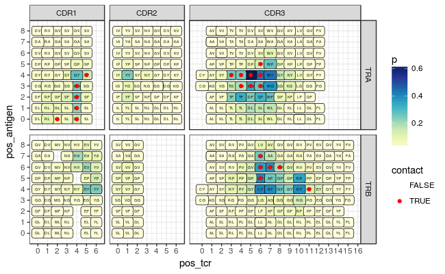

```r
df.pred.llf = df.pred %>%
  filter(antigen_seq == "LLFGYPVAV") %>%
  droplevels()
ggplot(df.pred.llf, aes(x=pos_tcr, y=pos_antigen)) +
  geom_tile(fill=NA) +
  geom_label(aes(label=paste(aa_tcr, aa_antigen, sep=":"), fill = p), cex=1.3) +
  geom_point(aes(color=contact)) +
  scale_x_continuous(breaks=0:20) +
  scale_y_continuous(breaks=0:20) +
  #scale_fill_gradient("P",
  #                    low="white", high="#045a8d") +
  scale_color_manual(values = c(NA, "red")) +
  scale_fill_gradientn(colors=colorRampPalette(brewer.pal(9, 'YlGnBu'))(32)) +
  facet_grid(tcr_chain ~ tcr_region, scales="free", space="free") +
  theme_bw()
```

# Independent validation

Computing contact map from fitted model for a specified TCR:pMHC setup

```r
compute_contact_map = function(mhc_type, tcr_chain, tcr_region, cdr_seq, ag_seq, id = "tmp") {
  cdr_seq = as.character(cdr_seq)
  ag_seq = as.character(ag_seq)
  df.cdr = data.frame(aa_tcr = strsplit(cdr_seq, "")[[1]],
                      pos_tcr = 1:nchar(cdr_seq) - 1)
  df.ag = data.frame(aa_antigen = strsplit(ag_seq, "")[[1]],
                      pos_antigen = 1:nchar(ag_seq) - 1)

  df.pairs = expand.grid(df.cdr$pos_tcr, df.ag$pos_antigen)
  colnames(df.pairs) = c("pos_tcr", "pos_antigen")

  df.pairs = merge(df.pairs, df.cdr)
  df.pairs = merge(df.pairs, df.ag)

  df.pairs$aa_pair = with(df.pairs,
                       as.factor(ifelse(as.character(aa_tcr) < as.character(aa_antigen),
                                        paste(aa_tcr, aa_antigen, sep = "_"), paste(aa_antigen, aa_tcr, sep = "_"))))

  df.pairs$mhc_type = mhc_type
  df.pairs$tcr_chain = tcr_chain
  df.pairs$tcr_region = tcr_region
  df.pairs$len_tcr = nchar(cdr_seq)
  df.pairs$len_antigen = nchar(ag_seq)

  df.pairs$pos_tcr_c = with(df.pairs, pos_tcr - round(len_tcr / 2))
  df.pairs$pos_antigen_c = with(df.pairs, pos_antigen - round(len_antigen / 2))

  df.pairs$id = id # ! id can be anything to group the complex, e.g. clonotype id in sample

  df.res = merge(df.pairs %>% select(id, mhc_type, tcr_chain, tcr_region, pos_tcr_c, pos_antigen_c, aa_antigen, aa_tcr, aa_pair),
        df.pred %>% select(mhc_type, tcr_chain, tcr_region, pos_tcr_c, pos_antigen_c, aa_pair, p, energy.mean), all.x = T) %>%
        unique()

  df.res$p[is.na(df.res$p)] = 0
  df.res$energy.mean[is.na(df.res$energy.mean)] = 0

  df.res
}
```

Testing - example 1 https://www.ncbi.nlm.nih.gov/pmc/articles/PMC2681418/ - engeneered peptide

```r
cm.tmp = compute_contact_map("MHCI","TRA","CDR3","CAVDSATSGTYKYIF","ILAKFLHWL","WT")
cm.tmp = rbind(cm.tmp, compute_contact_map("MHCI","TRA","CDR3","CAVDSATSGTYKYIF","ILAAFLHWL","No binding"))
cm.tmp = rbind(cm.tmp, compute_contact_map("MHCI","TRA","CDR3","CAVDSATSGTYKYIF","GLGGGGGGV","Mock"))
cm.tmp = rbind(cm.tmp, compute_contact_map("MHCI","TRA","CDR3","CAVDSATALPYGYIF","ILAKFLHWL", "Enhanced"))
print(cm.tmp %>% group_by(id) %>% summarize(contacts = sum(p), energy = sum(p * energy.mean)))
```

| id | contacts | energy |
| --- | --- | --- |
| Enhanced | 8.269807 | -58.66817 |
| Mock | 3.350889 | -18.29960 |
| No binding | 5.165294 | -24.74191 |
| WT | 7.955917 | -54.55842 |

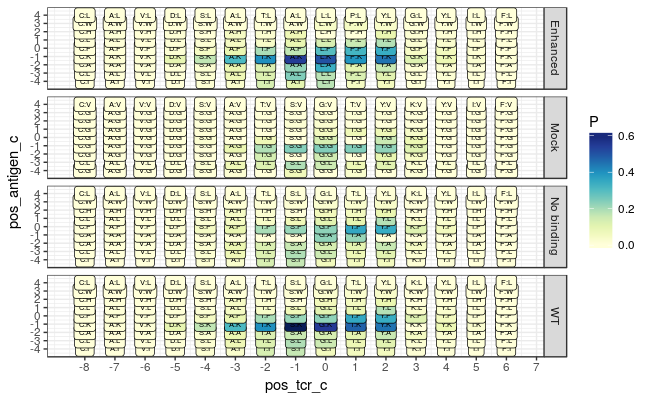

```r
ggplot(cm.tmp, aes(x=pos_tcr_c, y=pos_antigen_c)) +
  geom_tile(fill=NA) +
  geom_label(aes(label=paste(aa_tcr, aa_antigen, sep=":"), fill = p), cex=2) +
  scale_x_continuous(breaks=-8:9) +
  scale_y_continuous(breaks=-5:5) +
  scale_fill_gradientn("P", colors=colorRampPalette(brewer.pal(9, 'YlGnBu'))(32)) +
  facet_grid(id~., scales="free", space="free") +
  theme_bw()
```

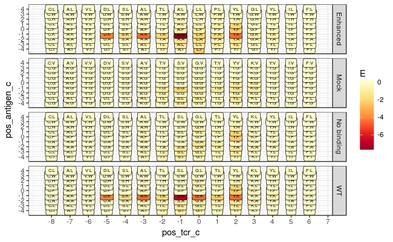

```r
ggplot(cm.tmp, aes(x=pos_tcr_c, y=pos_antigen_c)) +
  geom_tile(fill=NA) +
  geom_label(aes(label=paste(aa_tcr, aa_antigen, sep=":"), fill = p * energy.mean), cex=2) +
  scale_x_continuous(breaks=-8:9) +
  scale_y_continuous(breaks=-5:5) +
  scale_fill_gradientn("E", colors=rev(colorRampPalette(brewer.pal(9, 'YlOrRd'))(32))) +
  facet_grid(id~., scales="free", space="free") +
  theme_bw()
```

Testing - example 2 http://www.nature.com/articles/ncomms6223, https://www.ncbi.nlm.nih.gov/pmc/articles/PMC3049343/ - high affinity Tax mutant

```r
cm.tmp = compute_contact_map("MHCI","TRB","CDR3","CASRPGLAGGRPEQYF","LLFGYPVYV","WT")
cm.tmp = rbind(cm.tmp, compute_contact_map("MHCI","TRB","CDR3","CASRPGLMSAQPEQLF","LLFGYPVYV","High affinity"))
print(cm.tmp %>% group_by(id) %>% summarize(contacts = sum(p), energy = sum(p * energy.mean)))
```

| id | contacts | energy |
| --- | --- | --- |
| High affinity | 9.841837 | -84.70442 |
| WT | 8.145584 | -59.29974 |

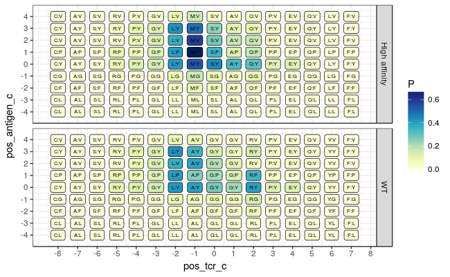

```r
ggplot(cm.tmp, aes(x=pos_tcr_c, y=pos_antigen_c)) +
  geom_tile(fill=NA) +
  geom_label(aes(label=paste(aa_tcr, aa_antigen, sep=":"), fill = p), cex=2) +
  scale_x_continuous(breaks=-8:9) +
  scale_y_continuous(breaks=-5:5) +
  scale_fill_gradientn("P", colors=colorRampPalette(brewer.pal(9, 'YlGnBu'))(32)) +
  facet_grid(id~., scales="free", space="free") +
  theme_bw()
```

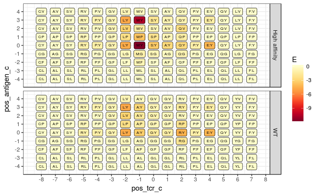

```r
ggplot(cm.tmp, aes(x=pos_tcr_c, y=pos_antigen_c)) +
  geom_tile(fill=NA) +
  geom_label(aes(label=paste(aa_tcr, aa_antigen, sep=":"), fill = p * energy.mean), cex=2) +
  scale_x_continuous(breaks=-8:9) +
  scale_y_continuous(breaks=-5:5) +
  scale_fill_gradientn("E", colors=rev(colorRampPalette(brewer.pal(9, 'YlOrRd'))(32))) +
  facet_grid(id~., scales="free", space="free") +
  theme_bw()
```

Testing - example 3 same as above - comparing Tax specific vs Tax and MART specific vs MART + cross-comparison. We compare CDR3beta of A6 (wild-type Tax-specific variant) and a MART-specific TCR derived from A6 by direct evolution.

```r
cm.tmp.1 = compute_contact_map("MHCI","TRB","CDR3","CASRPGLAGGRPEQYF","LLFGYPVYV","Tax-tcr:Tax")
cm.tmp.1 = rbind(cm.tmp, compute_contact_map("MHCI","TRB","CDR3","CASRPGLAGGRPEQYF","AAGIGILTV","Tax-tcr:MART"))
cm.tmp.1 = rbind(cm.tmp, compute_contact_map("MHCI","TRB","CDR3","CASRPGWMAGGVELYF","LLFGYPVYV","MART-tcr:Tax"))
cm.tmp.1 = rbind(cm.tmp, compute_contact_map("MHCI","TRB","CDR3","CASRPGWMAGGVELYF","AAGIGILTV","MART-tcr:MART"))
print(cm.tmp.1 %>% group_by(id) %>% summarize(contacts = sum(p), energy = sum(p * energy.mean)))
```

| id | contacts | energy |
| --- | --- | --- |
| High affinity | 9.841837 | -84.70442 |
| MART-tcr:MART | 7.354818 | -42.77908 |
| WT | 8.145584 | -59.29974 |

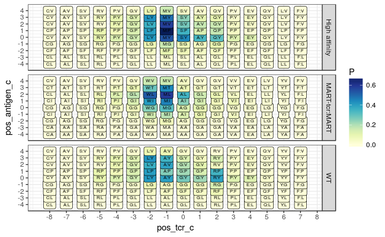

```r
ggplot(cm.tmp.1, aes(x=pos_tcr_c, y=pos_antigen_c)) +
  geom_tile(fill=NA) +
  geom_label(aes(label=paste(aa_tcr, aa_antigen, sep=":"), fill = p), cex=2) +
  scale_x_continuous(breaks=-8:9) +
  scale_y_continuous(breaks=-5:5) +
  scale_fill_gradientn("P", colors=colorRampPalette(brewer.pal(9, 'YlGnBu'))(32)) +
  facet_grid(id~., scales="free", space="free") +
  theme_bw()
```

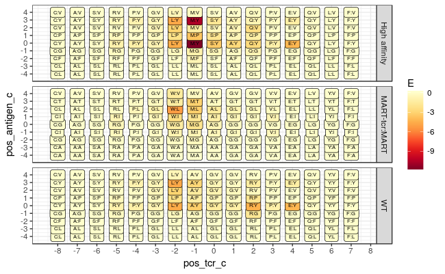

```r
ggplot(cm.tmp.1, aes(x=pos_tcr_c, y=pos_antigen_c)) +
  geom_tile(fill=NA) +
  geom_label(aes(label=paste(aa_tcr, aa_antigen, sep=":"), fill = p * energy.mean), cex=2) +
  scale_x_continuous(breaks=-8:9) +
  scale_y_continuous(breaks=-5:5) +
  scale_fill_gradientn("E", colors=rev(colorRampPalette(brewer.pal(9, 'YlOrRd'))(32))) +
  facet_grid(id~., scales="free", space="free") +
  theme_bw()
```

Same as above for alpha chains

```r
cm.tmp.2 = compute_contact_map("MHCI","TRA","CDR3","CAVVVTTDSWGKLQF","LLFGYPVYV","Tax-tcr:Tax")
cm.tmp.2 = rbind(cm.tmp, compute_contact_map("MHCI","TRA","CDR3","CAVVVTTDSWGKLQF","AAGIGILTV","Tax-tcr:MART"))
cm.tmp.2 = rbind(cm.tmp, compute_contact_map("MHCI","TRA","CDR3","CAVVVTKYSWGKLQF","LLFGYPVYV","MART-tcr:Tax"))
cm.tmp.2 = rbind(cm.tmp, compute_contact_map("MHCI","TRA","CDR3","CAVVVTKYSWGKLQF","AAGIGILTV","MART-tcr:MART"))
print(cm.tmp.2 %>% group_by(id) %>% summarize(contacts = sum(p), energy = sum(p * energy.mean)))
```

| id | contacts | energy |
| --- | --- | --- |
| High affinity | 9.841837 | -84.70442 |
| MART-tcr:MART | 6.857838 | -42.29902 |
| WT | 8.145584 | -59.29974 |

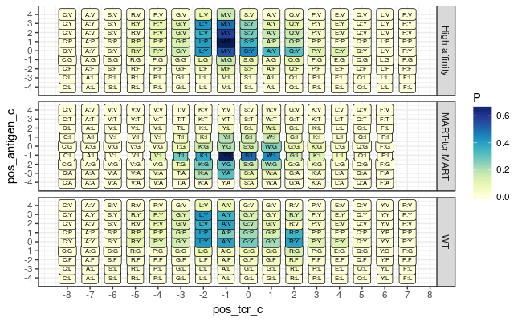

```r
ggplot(cm.tmp.2, aes(x=pos_tcr_c, y=pos_antigen_c)) +
  geom_tile(fill=NA) +
  geom_label(aes(label=paste(aa_tcr, aa_antigen, sep=":"), fill = p), cex=2) +
  scale_x_continuous(breaks=-8:9) +
  scale_y_continuous(breaks=-5:5) +
  scale_fill_gradientn("P", colors=colorRampPalette(brewer.pal(9, 'YlGnBu'))(32)) +
  facet_grid(id~., scales="free", space="free") +
  theme_bw()
```

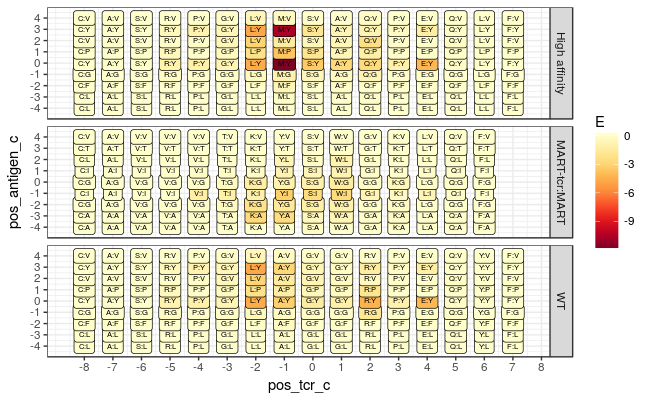

```r
ggplot(cm.tmp.2, aes(x=pos_tcr_c, y=pos_antigen_c)) +
  geom_tile(fill=NA) +
  geom_label(aes(label=paste(aa_tcr, aa_antigen, sep=":"), fill = p * energy.mean), cex=2) +
  scale_x_continuous(breaks=-8:9) +
  scale_y_continuous(breaks=-5:5) +
  scale_fill_gradientn("E", colors=rev(colorRampPalette(brewer.pal(9, 'YlOrRd'))(32))) +
  facet_grid(id~., scales="free", space="free") +
  theme_bw()
```

Summarize alpha and beta chains

```r
print(rbind(cm.tmp.1, cm.tmp.2) %>% group_by(id) %>% summarize(contacts = sum(p), energy = sum(p * energy.mean)))
```

| id | contacts | energy |
| --- | --- | --- |
| High affinity | 19.68367 | -169.4088 |
| MART-tcr:MART | 14.21266 | -85.0781 |
| WT | 16.29117 | -118.5995 |